# Chicago Divvy Bicycle Sharing data

### Using the information from bike riding to gain insights

Sharing bicycles in a City environment promotes a lot of good habits. It's much more environmentally friendly than car travel, it can be a social experience, and it keeps you in shape.

This dataset is a combined dataset of bicycle sharing company Divvy and a weather dataset as well, detailing the temperature and weather outside during each ride

## Why do we care?

Gaining insights into a customer base is a big part of Data Science. Before we even begin to query the dataset, there are questions we can daydream about:

- Can we predict how long a customer will ride?
- If customers use this to commute to work can we find that out from consistency?
- What stations are the most / least popular?

Being able to understand the customer base more will only help a company like Divvy be able to provide better service to them.

Let's explore the data

### Cleaning the Data / Feature Engineering

```python
df.info()
```

```
<class 'pandas.core.frame.DataFrame'>
RangeIndex: 9495235 entries, 0 to 9495234
Data columns (total 23 columns):
trip_id              int64
year                 int64
month                int64
week                 int64
day                  int64
hour                 int64
usertype             object
gender               object
starttime            object
stoptime             object
tripduration         float64
temperature          float64
events               object
from_station_id      int64
from_station_name    object
latitude_start       float64
longitude_start      float64
dpcapacity_start     float64
to_station_id        int64
to_station_name      object
latitude_end         float64
longitude_end        float64
dpcapacity_end       float64
dtypes: float64(8), int64(8), object(7)
memory usage: 1.6+ GB
```

There is a lot of interesting information to look at already

- Date / time variables are conveniently split for us
- Temperature, weather events are provided for each trip
- Detailed information about each station, including co-ordinates

What can we feature-engineer using this data?

Using just the latitude and longitude start and end, we can determine what direction the customer was heading on their bike ride.

```python
# Directions. Opposites are not included as these are boolean values, so they will just be the 0
df['north'] = df.latitude_start > df.latitude_end
df['east'] = df.longitude_start > df.longitude_end
df['northeast'] = df.north & df.east
df['southeast'] = ~df.north & df.east

# Converting to datetime types
df['starttime'] = pd.to_datetime(df['starttime'])
df['stoptime'] = pd.to_datetime(df['stoptime'])
```

We can also get the euclidean (straight line) distance by looking at the start and end co-ordinates for each bike ride

It would be possible to use Google Map's API to be able to get a more accurate distance estimate, which would be a fun thing to do in the future with this dataset, but that costs money so this is a good enough replacement for our purposes

```python
import geopy.distance
def distance_calc(row):
    c1 = (row.latitude_start, row.longitude_start)
    c2 = (row.latitude_end, row.longitude_end)

    return(geopy.distance.geodesic(c1, c2).miles)
df['distance'] = df.apply(distance_calc, axis = 1)
```

We have two datetime objects within the dataframe. It's much easier to try and work with machine learning techniques on datetime columns if we just split up the data into easier values to digest, such as minutes, hours, days, months, etc.

```python
### This function will take in a datetime object, explode it into these values:
### - day
### - month
### - year
### - minute
### - hour
### - second
### - microsecond
### Can drop the column afterwards if you wishs
def engineerDateTimes(colname, engineerName, data, drop = False):
# Make sure it's a datetime column
    assert data[colname].dtype == '<M8[ns]', 'column not of datetime type'
    # Locations where value exists
    truths = ~df[colname].isna()
    # Extract the date and time from column
    df_date, df_time = zip(*[(d.date(), d.time()) for d in data[truths][colname]])
# Dates
    data.loc[truths, engineerName + '_day'] = [d.day for d in df_date]
    data.loc[truths, engineerName + '_month'] = [d.month for d in df_date]
    # Year is already accounted for within 'year'
#    data.loc[truths, engineerName + '_year'] = [d.year for d in df_date]
# Times
    data.loc[truths, engineerName + '_minute'] = [d.minute for d in df_time]
    data.loc[truths, engineerName + '_hour'] = [d.hour for d in df_time]
    # All seconds are 0
#    data.loc[truths, engineerName + '_second'] = [d.second for d in df_time]
    # All the microseconds in this dataset are 00, so there's no point in making a column for them
#    data.loc[truths, engineerName + '_microsecond'] = [d.microsecond for d in df_time]
# Drop
    if (drop == True):
        return(data.drop([colname], axis = 1))

    return(data)
```

```python
df = engineerDateTimes(colname ='starttime',
                  engineerName = 'start',
                  data = df)
df = engineerDateTimes(colname ='stoptime',
                  engineerName = 'stop',
                  data = df)
```

### Exploring the data

By just looking at the starting latitude and longitude, we can see a distribution of how the biking stations are setup within the city

```python
# This is using syntax from the package dfplyr, which is designed to mimic R's dplyr syntax within python
stations = (df >>
    group_by(X.longitude_start,
             X.latitude_start) >>
    summarize(count = n(X.longitude_start)) >>
    #ungroup() >>
    arrange(X.count) >>
    ungroup()
    #filter_by(X.count > 0)
)
#stations
```

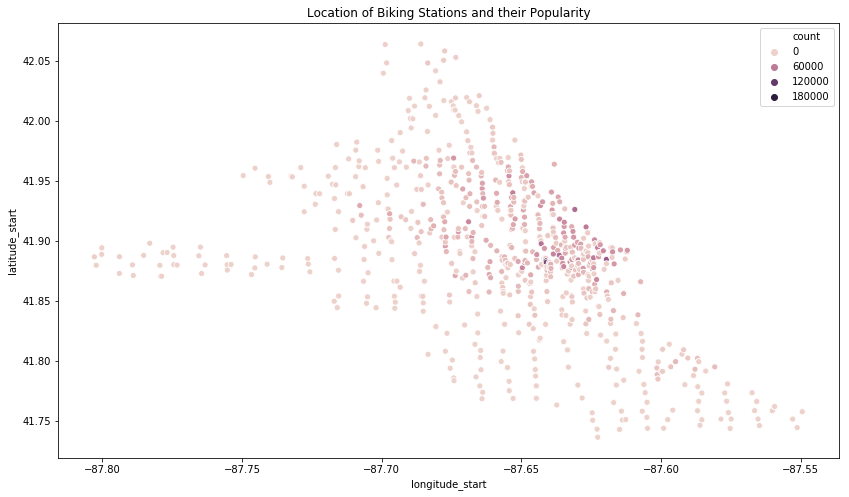

```python
plt.figure(figsize=(global_width, global_height))
sns.scatterplot(data = stations,
                x = 'longitude_start',
                y = 'latitude_start',
                hue = 'count')
ax = plt.gca()
ax.set_title("Location of Biking Stations and their Popularity")
plt.show()
```

This clustering of bike-stations make sense. Near the center of the city there is a heavier density of bike stations, and the further away from the center they become more spread out, especially to the Southeast and West

By using the popularity of each station as a color we can see the majority of users ride bikes within the center of the city

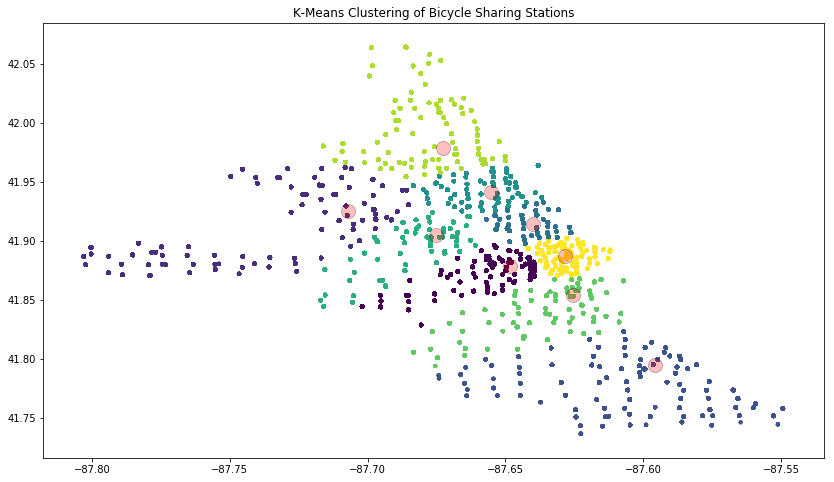

```python
from sklearn.cluster import KMeans
kmeans = KMeans(n_clusters=9)
X = df[['longitude_start', 'latitude_start']]
kmeans.fit(X)
y_kmeans = kmeans.predict(X)

plt.figure(figsize=(global_width, global_height))
plt.scatter(X['longitude_start'], X['latitude_start'], c=y_kmeans, s = 10)

centers = kmeans.cluster_centers_
plt.scatter(centers[:, 0], centers[:, 1], c='red', s=200, alpha=0.25, edgecolors = 'black')

ax = plt.gca()
ax.set_title("K-Means Clustering of Bicycle Sharing Stations")
plt.show()
```

I was curious how k-means clustering would handle dividing up the bike stations, and if it would come close to matching the district borders in the city. It didn't come close to that, but it was still interesting to see how it clustered them

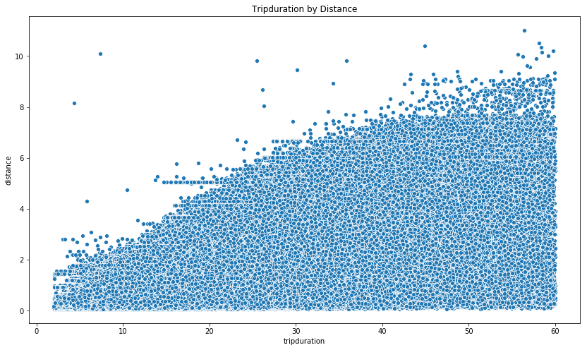

```python
plt.figure(figsize=(global_width, global_height))
sns.scatterplot(data = df[df.distance > 0],
                x = 'tripduration',
                y = 'distance')
ax = plt.gca()
ax.set_title("Tripduration by Distance")
plt.show()
```

In general we see that distance increases as trip duration does

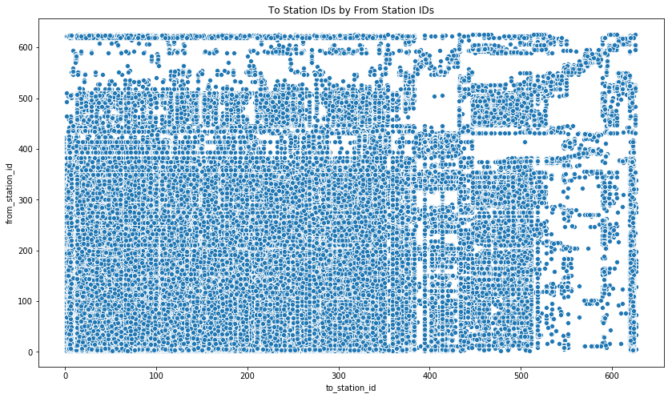

```python
plt.figure(figsize=(global_width, global_height))
sns.scatterplot(data = df,
                x = 'to_station_id',
                y = 'from_station_id')
ax = plt.gca()
ax.set_title("To Station IDs by From Station IDs")
plt.show()
```

# Preprocessing

We've already done some feature enginnering to get some more information for predictions, now it's time to get ready for machine learning.

This upcoming code is going to accomplish two tasks:

```
- Convert all categorical variables into numerical representations with OneHotEncoding techniques
- Standardize all numerical columns into z-scores to help with processing
```

I would have utilized OneHotEncoding but my computer doesn't have the memory to handle it. So I stuck with just standard scalar

```python
# Get a list of columns
cols = df.columns

### Takes in a default prediction column of tripduration, but can be changed
### Also takes in a default dataframe of df, but if you want to filter the data before-hand just send in a relevant slice
### num_impute is how to handle missing numerical values, default is median, if there are no missing values than
###   nothing will be affected!
### cat_impute determines how you can impute missing categorical values, check SimpleImputer documentation for more
### cat_impute_fill is what to replace the missing categorical values with if cat_impute is set to 'constant'
### data is the data that you want to preprocess
def preprocess_data(data, prediction_column,
                    num_impute = 'median', cat_impute = 'constant', cat_impute_fill = 'MISSING'):
    df_process = data.copy()
# data handling
    # The column must be assigned before dropping it
    y = df_process[prediction_column]
    df_process = df_process.drop([prediction_column], axis = 1)
# column type handling
    kinds = np.array([dt.kind for dt in df_process.dtypes])
    all_columns = df_process.columns.values
    is_cat = kinds == 'O'
    # For integer or bools
    is_num = kinds != 'O'
    # An array of all integer / bool columns
    num_cols = all_columns[is_num]
#    print(num_cols)
    # An array of all categorical columns
    cat_cols = all_columns[is_cat]
# Machine learning pipeline preparation
 # Numeric
    # Imputation
    num_si_step = ('si', SimpleImputer(strategy = num_impute))
    # Scaling data
    num_ss_step = ('ss', StandardScaler())
    # All steps for numeric columns
    num_steps = [num_si_step, num_ss_step]
    # Create a pipeline of the steps
    num_pipe = Pipeline(num_steps)
    # Create the transformation tuple for the numeric steps
    num_transformers = [('num', num_pipe, num_cols)]
 # Categorical
    # Same steps as above, but for categorical columns instead
#     cat_si_step = ('si', SimpleImputer(strategy = cat_impute,
#                                   fill_value = cat_impute_fill))
#     cat_ohe_step = ('ohe', preprocessing.OneHotEncoder(sparse = False,
#                                     handle_unknown = 'ignore'))
#     cat_steps = [cat_si_step, cat_ohe_step]
#     cat_pipe = Pipeline(cat_steps)
# Transformations / Pipeline
    # List of all transformations that will be put into the pipe, this also determines which operations will affect
    # what columns
    transformers = [#('cat', cat_pipe, cat_cols),
                    ('num', num_pipe, num_cols)]
    ct = ColumnTransformer(transformers = transformers)
    data_pro = ct.fit_transform(data)

    return(y, data_pro)
```

# Machine Learning

## Predicting Trip Duration

It would be nice to be able to utilize the data about a biker / weather to be able to know how long their trip is going to last. Let's see how accurately we can predict that

```python
cols_to_drop = ['trip_id', 'to_station_id', 'from_station_id', 'starttime', 'stoptime',
                'start_day', 'start_month', 'start_minute', 'start_hour', 'stop_day',
                'stop_month', 'stop_minute', 'stop_hour']
y_pro, df_pro = preprocess_data(df.drop(cols_to_drop, axis = 1),
                                prediction_column = 'tripduration')

#get train and test
X_train, X_test, y_train, y_test = train_test_split(df_pro,
                                                    y_pro,
                                                    test_size = 0.30,
                                                    random_state = 0)
                                                    #random_state = random.randint(0, 100))

#fit model on training data
linReg = linear_model.LinearRegression()
linReg.fit(X_train, y_train)

y_preds = linReg.predict(X_test)

#score on test data
print("Accuracy score for the tripduration linear regression model: % 0.02f" % linReg.score(X_test, y_test))
```

```
Accuracy score for the tripduration linear regression model:  0.64
```

An 0.64 accuracy score isn't bad! I do use a random seed in the train_test_split, so let's see how accurate that score it, as well as seeing as strong this model is for new and upcoming data using cross-validation

```python
scores = cross_val_score(linReg, X_train, y_train, cv=10, scoring = 'r2')
print("Linear model accuracy on tripduration: %0.2f (+/- %0.2f)" % (scores[scores > 0].mean(),
                                                                    scores[scores > 0].std() * 2))
#print("Linear model accuracy on tripduration: %0.2f (+/- %0.2f)" % (scores.mean(), scores.std() * 2))
```

```
Linear model accuracy on tripduration: 0.64 (+/- 0.00)
```

It looks like that score was an accurate representation of the model! With a standard deviation that small, it looks like this is about as strong as a linear model can work on predicting tripduration. Let's take a look at some other models

```python
MSE = mean_squared_error(y_test, y_preds)
print("MSE: " + str(MSE))
RMSE = np.sqrt(MSE)
print("RSME: " + str(RMSE))
```

```
MSE: 18.58871169626141
RSME: 4.311462825568766
```

Along with cross_val_score evaluation, I will also be utilizing Mean Squared Eror (MSE) / Root Mean Squared Error (RMSE) to test the strength of the different models

```python
cols_to_drop = ['trip_id', 'to_station_id', 'from_station_id', 'starttime', 'stoptime',
                'start_day', 'start_month', 'start_minute', 'start_hour', 'stop_day',
                'stop_month', 'stop_minute', 'stop_hour']
y_pro, df_pro = preprocess_data(df_sample.drop(cols_to_drop, axis = 1),
                                prediction_column = 'tripduration')

#get train and test
X_train, X_test, y_train, y_test = train_test_split(df_pro,
                                                    y_pro,
                                                    test_size = 0.30,
                                                    random_state = 0)
                                                    #random_state = random.randint(0, 100))

knnReg = KNeighborsRegressor(10)
knnReg.fit(X_train, y_train)

y_preds = knnReg.predict(X_test)

#score on test data
print("Accuracy score for the tripduration kNN model w/ 10 neighbors: % 0.02f" % knnReg.score(X_test, y_test))
```

```
Accuracy score for the tripduration kNN model w/ 10 neighbors:  0.55
```

```python
scores = cross_val_score(knnReg, X_train, y_train, cv=10, scoring = 'explained_variance')
print("kNN model accuracy on tripduration: %0.2f (+/- %0.2f)" % (scores[scores > 0].mean(),
                                                                    scores[scores > 0].std() * 2))
#print("Linear model accuracy on tripduration: %0.2f (+/- %0.2f)" % (scores.mean(), scores.std() * 2))
```

```
kNN model accuracy on tripduration: 0.56 (+/- 0.05)
```

```python
MSE = mean_squared_error(y_test, y_preds)
print("MSE: " + str(MSE))
RMSE = np.sqrt(MSE)
print("RSME: " + str(RMSE))
```

```
MSE: 24.634934503703704
RSME: 4.96335919551504
```

kNN was lower across the board for predicting tripduration against every metric

```python
tree = DecisionTreeRegressor(max_depth=7)
tree.fit(X_train, y_train)
y_preds = tree.predict(X_test)

print("Accuracy score for the tripduration Decision Tree Regressor model w/ 7 neighbors: % 0.02f" %
      tree.score(X_test,y_test))
```

[output not shown]

```python
scores = cross_val_score(tree, df_pro, y_pro, cv=10)
print("Decision Tree Regressor accuracy on tripduration: %0.2f (+/- %0.2f)" % (scores.mean(), scores.std() * 2))
```

```
Decision Tree Regressor accuracy on tripduration: 0.69 (+/- 0.03)
```

```python
MSE = mean_squared_error(y_test, y_preds)
print("MSE: " + str(MSE))
RMSE = np.sqrt(MSE)
print("RSME: " + str(RMSE))
```

```
MSE: 16.326024953244406
RSME: 4.040547605615408
```

It looks like a Decision Tree is the best predictor for this model, with a stronger accuracy, MSE and RMSE

## Predicting the direction traveled by the customer

There are multiple different directions that I feature-engineered earlier using the data

- north
- east
- northeast
- southeast

For this example I chose to predict **north** but any one of the directions could be predicted

### Why is this important?

Well, if you are able to predict what direction someone is heading, you can more easily determine what stations they are likely to head to.

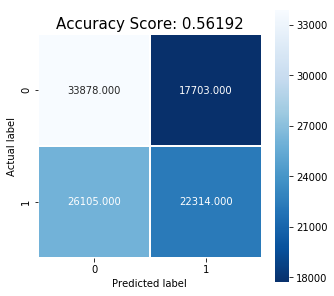

```python
# In order to make this a 'fair' direction prediction, we have to drop a lot of columns. This is beacuse the directions are
# feature-engineered from latitude / longitdue. We need to drop all other directions that are feature-engineered from that
# And if we know what station they end at, we already know what direction they were heading
cols_to_drop = ['trip_id', 'to_station_id', 'from_station_id', 'starttime', 'stoptime',
                'longitude_start', 'longitude_end', 'latitude_start', 'latitude_end',
                'east', 'southeast', 'northeast', 'to_station_name']
y_pro, df_pro = preprocess_data(df.drop(cols_to_drop, axis = 1),
                                prediction_column = 'north')

X_train, X_test, y_train, y_test = train_test_split(df_pro,
                                                    y_pro,
                                                    test_size=0.20,
                                                    random_state = random.randint(0,100))

mult_log_reg = linear_model.LogisticRegression()
mult_log_reg.fit(X_train,y_train)
mult_log_score = mult_log_reg.score(X_test, y_test)
mult_log_predict = mult_log_reg.predict(X_test)

cm = confusion_matrix(y_test, mult_log_predict)

plt.figure(figsize=(5, 5))
sns.heatmap(cm, annot=True, fmt=".3f", linewidths=.5, square = True, cmap = 'Blues_r');
plt.ylabel('Actual label');
plt.xlabel('Predicted label');
all_sample_title = 'Accuracy Score: {0}'.format(mult_log_score)
plt.title(all_sample_title, size = 15);
```

```python
scores = cross_val_score(mult_log_reg, X_test, y_test, cv=10, scoring = 'accuracy')
print("Logistic model accuracy on North: %0.2f (+/- %0.2f)" % (scores[scores > 0].mean(), scores[scores > 0].std() * 2))
```

```
Logistic model accuracy on North: 0.56 (+/- 0.01)
```

Even after dropping any columns that would be considered 'cheating', we have an alright Logistic Model for predicting whether the customer was heading North or South.

```python
#baseline accuracy only using all 1s as a prediction
all_ones = np.zeros(len(y_train))
print('baseline zeros accuracy: ', accuracy_score(y_train, all_ones))
```

```
baseline zeros accuracy:  0.5144925
```

Checking against just a baseline 0 accuracy, it's only a little over 50%, and we've beaten that already! Let's try another model

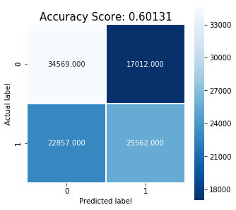

```python
tree = DecisionTreeClassifier(max_depth=10)
tree.fit(X_train, y_train)
y_preds = tree.predict(X_test)

cm = confusion_matrix(y_test, y_preds)

plt.figure(figsize=(5, 5))
sns.heatmap(cm, annot=True, fmt=".3f", linewidths=.5, square = True, cmap = 'Blues_r');
plt.ylabel('Actual label');
plt.xlabel('Predicted label');
all_sample_title = 'Accuracy Score: {0}'.format(tree.score(X_test,y_test))
plt.title(all_sample_title, size = 15);
```

```python
scores = cross_val_score(tree, X_test, y_test, cv=10)
print("Decision Tree model on North: %0.2f (+/- %0.2f)" % (scores[scores > 0].mean(),
                                                                    scores[scores > 0].std() * 2))
```

```
Decision Tree model on North: 0.59 (+/- 0.01)
```

It looks like a Decision Tree is just a little bit stronger at predicting a direction!

# Conclusion

Given more time there's still more I'd like to explore with the dataset

- Being able to work with Google's API to get more proper distances between each of the stations
- To be able to create a model that could attempt to predict each cardinal / intercardinal direction

Taking a deeper look into the dataset of a proper company presented it's own challenges and intrigues. I look forward to exploring more real world datasets and trying to find insights using the power of Machine Learning